# Mid Term

Nzambuli Daniel

2024-02-21

# Given Information

**Parameter list**

- Contact Rate (12)
- Transmission Probability (0.03)
- Infectiousness Period (12)
- Latency Period (21)

```r
Cont.Rate = 12
Trans.Prob = 0.03
Inf.Per = 12
Lat.Per = 21
```

**Disease Dynamic Parameter and Initial Values**

- Exposed (15,000)
- Susceptible (20,989)
- Infected (11)
- Recovered (0)
- Dead (0)

```r
exposed = 15000
susceptible = 20989
infected = 11
recovered = 0
dead = 0
```

**State Values**

- Susceptible: susceptible/Total population
- Exposed: exposed/Total population
- Infected: infected/Total population
- Recovered: recovered/Total population
- Hospitalized: hospitalized/Total population
- Dead: dead/Total population

```r
N = susceptible + exposed + infected + dead + recovered
susc = susceptible /N
expsd = exposed/N
infct = infected/N
dead = dead/N
recvd = recovered/N

monitor.time = 100
```

# Task

## 1.) Present the Schematic Framework illustrate the compartments and interactions between age-groups. Remember that susceptible children experience the force of infection, while susceptible adults become infected at a constant rate. For this case assume that:

- Children make 20 contacts per day on average, with 12 contacts being with other children.
- Adults make 19 contacts per day on average, with 15 contacts being with other adults.

### Load Libraries

```r
library(deSolve)
library(tidyverse)
library(DiagrammeR)
```

```r
grViz("digraph flowchart {
      graph [layout = dot,
       rankdir = LR]
      node [fontname = Helvetica, shape = circle,]
      tab1 [label = '@@1', fillcolor = '#41c542', style = filled]
      tab2 [label = '@@2', fillcolor = '#8c9647', style = filled]
      tab3 [label = '@@3', fillcolor = '#8d9647', style = filled]
      tab4 [label = '@@4', fillcolor = '#b17e4a', style = filled]
      tab5 [label = '@@5', fillcolor = '#b27e4a', style = filled]
      tab6 [label = '@@6', fillcolor = '#fc4f4f', style = filled]
      tab7 [label = '@@7', fillcolor = '#fd4f4d', style = filled]
      tab8 [label = '@@8', fillcolor = '#1cdd3f', style = filled]
      tab9 [label = '@@9', fillcolor = '#1ddd3f', style = filled]
      # edge definitions with the node IDs
      tab1 -> tab2 [label = 'beta child'];
      tab1 -> tab3 [label = 'beta adult'];
      tab2 -> tab4 [label = 'kappa child'];
      tab4 -> tab6 [label = 'mu child'];
      tab4 -> tab8 [label = 'gamma child'];
      tab3 -> tab5 [label = 'kappa adult'];
      tab5 -> tab7 [label = 'mu adult'];
      tab5 -> tab9 [label = 'gamma adult'];
      }

      [1]: 'Susceptible'
      [2]: 'Exposed Children'
      [3]: 'Exposed Adults'
      [4]: 'Infected Children'
      [5]: 'Infected Adult'
      [6]: 'Dead Children'
      [7]: 'Dead Adults'
      [8]: 'Recovered Children'
      [9]: 'Recovered Adults'
      ")
```

[interactive chart not shown]

### Illustrating the interactions between children and adults

```r
grViz("digraph flowchart {
      graph [layout = dot,
       rankdir = LR]
      node [fontname = Helvetica, shape = circle,]
      tab1 [label = '@@1', fillcolor = '#41c542', style = filled]
      tab2 [label = '@@2', fillcolor = '#8c9647', style = filled]

      # edge definitions with the node IDs
      tab1 -> tab2 [label = '8'];
      tab1 -> tab1 [label = '12'];
      tab2 -> tab1 [label = '4'];
      tab2 -> tab2 [label = '15'];
      }

      [1]: 'child'
      [2]: 'adult'
      ")
```

[interactive chart not shown]

```r
c2a.Contact = 8
c2c.Contact = 12
a2a.Contact = 15
a2c.Contact = 4
```

### Kappa Beta and Gamma

> 1. $\beta$ **Beta**

> **Transmission coefficient** – The average number of `infectious contacts` an infected infectious individual makes each time period. *High beta* means that the disease has `more opportunity` to spread.

> $$\beta = contact\ rate∗transmission\ probability$$
> 2. $\sigma$ **Sigma** or $\delta$ **Delta**

> **Exposed individuals become infectious** – The reciprocal of the average time it takes to become infectious. Exposion rate.

> $$\sigma = \frac{1}{latency\ period}$$
> 3. $\gamma$ **Gamma**

> **Rate of Recovery** – the reciprocal of the average time it takes to recover.

> $$\gamma = \frac {1}{infectious\ period}$$
> 4. $\mu$ **Mu**

> **Mortality rate** – mortality rate of infectious individuals.

> the higher the $\mu$ the more deadly the disease is

> **Reproduction Number**

> $$Reproduction\ number = \frac{\beta}{\gamma}$$

```r
beta = Cont.Rate * Trans.Prob
sigma = 1/Lat.Per
gamma = 1/Inf.Per
mu = 1/Inf.Per
```

### Assumptions on the population

> **Children are 30%** of the population
> - because children experience the weight of infection the adults are considered to be all the infected individuals.

```r
S.child = 0.3 * (susc)
S.adult = 0.7 * (susc)
I.child = 0
I.adult = infct
E.child = 0.3 * expsd
E.adult = 0.7 * expsd
R.child = 0
R.adult = 0
D.child = 0
D.adult = 0
N = S.child + S.adult + I.child + I.adult + E.child + E.adult + R.child + R.adult + D.child + D.adult # population expressed as a proportion should equal 1
N
```

```
## [1] 1
```

> **Proportional Parameters**
> - Children have been considered as 30% of the population
> - N expresses the population as a parameter expressed as a sum of all the people in who are susceptible, infected, exposed, recovered and dead.
> - At any point N remains constant

## 2.) Simulate the SEIR Epidemic based on the provided parameters and initial values.

**Differential Equations**

- susceptible individuals

$$weight\ of\ infection\ \lambda = \beta * (Child-to-Child *
\frac{infected\ children}{no.\ children} + Child-to-Adult *
\frac{infected\ adult}{no.\ adult}\\
\frac{dS_{children}}{dt} = -\lambda * S_{children}\\
infected\ adult\ \beta.a = (\beta * \frac{infected\ adult}{no.\ Adult})
*(Adult-to-Adult + Adult-to-Child)\\
\frac{dS_{adult}}{dt} = -\beta * S_{adult}$$

- Exposed individuals

$$\frac{dE_{children}}{dt} = \lambda * S_{children} - \sigma *
E_{children}\\
\frac{dE_{adult}}{dt} = \beta * S_{adult} - \sigma * E_{adult}$$

- Infected individuals

$$\frac{dI_{children}}{dt} = \sigma * E_{children} - (\gamma + \mu)
I_{children}\\
\frac{dI_{adult}}{dt} = \sigma * E_{adult} - (\gamma + \mu) I_{adult}$$

- recovered individuals

$$\frac{dR_{children}}{dt} = \gamma * I_{children}\\
\frac{dR_{adult}}{dt} = \gamma * I_{adult}$$

- dead individuals

$$\frac{dR_{children}}{dt} = \mu * I_{children}\\
\frac{dR_{adult}}{dt} = \mu * I_{adult}$$

### a.) Define the SEIR model equations incorporating age-group-specific contact rates.

```r
seir.d = function(time, state, parameters){
  S.c = state[1]
  S.a = state[2]
  E.c = state[3]
  E.a = state[4]
  I.c = state[5]
  I.a = state[6]
  R.c = state[7]
  R.a = state[8]
  D.c = state[9]
  D.a = state[10]
  with(as.list(parameters), {
    N.c = S.c + E.c + I.c + R.c + D.c
    N.a = S.a + E.a + I.a + R.a + D.a

    # weight of infection
    lambda = (beta * c2c * I.c/N.c) + (beta * c2a * I.a/N.a)

    # adults have a constant infection rate
    beta.a = (a2a * beta * I.a/N.c) +  (a2c * beta * I.a/N.a)

    # define the differential equations

    # child differential equations
    dSc = - lambda * S.c
    dEc = lambda * S.c - sigma * E.c
    dIc = sigma * E.c - (gamma + mu) * I.c
    dRc = gamma * I.c
    dDc = mu * I.c

    # adult differential equations
    dSa = - beta.a * S.a
    dEa = beta.a * S.a - sigma * E.a
    dIa = sigma * E.a - (gamma + mu) * I.a
    dRa = gamma * I.a
    dDa = mu * I.a

    # return the output of the differential equations
    return(list(c(dSc, dSa, dEc, dEa, dIc, dIa, dRc, dRa, dDc, dDa)))

  })
}
```

### b.) Utilize the provided initial values to simulate the epidemic over a 100-day period.

```r
parameters = c(b = beta, mu = mu, sigma = sigma, gamma = gamma, c2c = c2c.Contact, c2a = c2a.Contact, a2a = a2a.Contact, a2c = a2c.Contact)
state = c(S.child = S.child, S.adult = S.adult,
          E.child = E.child, E.adult = E.adult,
          I.child = I.child, I.adult = I.adult,
          R.child = R.child, R.adult = R.adult,
          D.child = D.child, D.adult = D.adult)
time = seq(0, 100, 1)
```

#### Simulate the model

```r
no_Hosp = as.data.frame(ode(y = state, times = time, func = seir.d, parms = parameters))
head(no_Hosp)
```

```
##   time    S.child     S.adult   E.child   E.adult     I.child      I.adult
## 1    0 0.17490833 0.408119444 0.1250000 0.2916667 0.000000000 0.0003055556
## 2    1 0.16319765 0.354839649 0.1307084 0.3305016 0.005532386 0.0135882290
## 3    2 0.13319965 0.234324382 0.1539803 0.4329627 0.010892807 0.0281953134
## 4    3 0.09403282 0.112560333 0.1850830 0.5316174 0.016667522 0.0452135319
## 5    4 0.05663135 0.038018956 0.2129745 0.5794769 0.022885618 0.0628783876
## 6    5 0.02905729 0.009139404 0.2299525 0.5806027 0.029142655 0.0787899668
##        R.child      R.adult      D.child      D.adult
## 1 0.0000000000 0.0000000000 0.0000000000 0.0000000000
## 2 0.0002349704 0.0005810943 0.0002349704 0.0005810943
## 3 0.0009177941 0.0023046592 0.0009177941 0.0023046592
## 4 0.0020624729 0.0053501769 0.0020624729 0.0053501769
## 5 0.0037084557 0.0098587308 0.0037084557 0.0098587308
## 6 0.0058779353 0.0157798151 0.0058779353 0.0157798151
```

#### Plot the model

```r
long_no_hosp <- no_Hosp %>%  pivot_longer(cols = c("S.child", "S.adult", "E.child", "E.adult", "I.child", "I.adult","R.child", "R.adult", "D.child", "D.adult"),
                        names_to = "state",
                        values_to = "value")
head(long_no_hosp)
```

```
## # A tibble: 6 × 3
##    time state      value
##   <dbl> <chr>      <dbl>
## 1     0 S.child 0.175
## 2     0 S.adult 0.408
## 3     0 E.child 0.125
## 4     0 E.adult 0.292
## 5     0 I.child 0
## 6     0 I.adult 0.000306
```

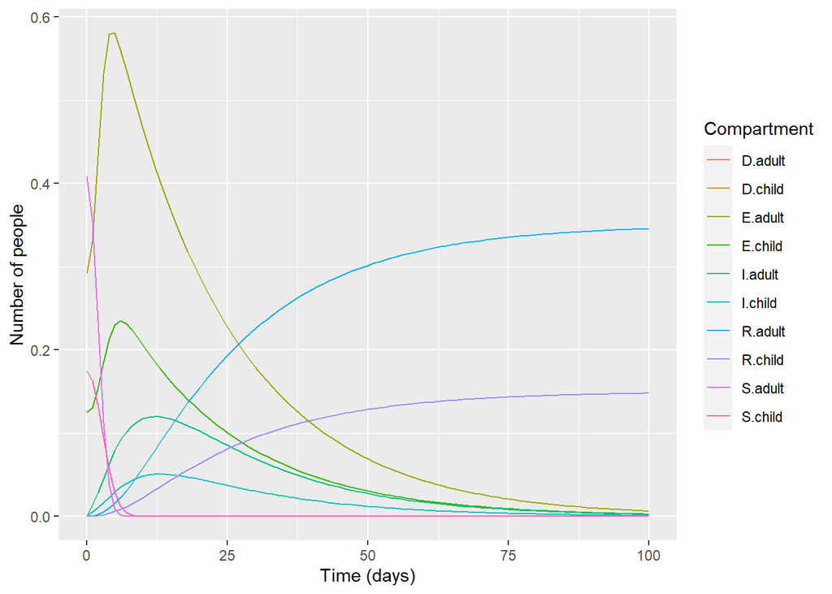

```r
# The plot
ggplot(data = long_no_hosp,
       aes(x = time, y = value, colour = state, group = state)) +
  geom_line() +
  xlab("Time (days)")+
  ylab("Number of people") +
  labs(colour = "Compartment")
```

#### split the data

```r
create_child_plot = function(data){
  child_data = data[, c("time","S.child", "E.child", "I.child", "R.child", "D.child")]
  child_long <- child_data %>%  pivot_longer(cols = c(S.child, E.child, I.child, R.child, D.child),
                        names_to = "state",
                        values_to = "value")
  plot = ggplot(data = child_long,
                aes(x = time, y = value, colour = state, group = state)) +
    geom_line() +
    xlab("Time (days)")+
    ylab("Number of people") +
    labs(colour = "Compartment")
  print(plot)
}
```

```r
create_adult_plot = function(data){
  adult_data = data[, c("time","S.adult", "E.adult", "I.adult", "R.adult", "D.adult")]
  adult_long <- adult_data %>%  pivot_longer(cols = c(S.adult, E.adult, I.adult, R.adult, D.adult),
                        names_to = "state",
                        values_to = "value")
  plot = ggplot(data = adult_long,
                aes(x = time, y = value, colour = state, group = state)) +
    geom_line() +
    xlab("Time (days)")+
    ylab("Number of people") +
    labs(colour = "Compartment")
  print(plot)
}
```

> - all the infected individuals are adults with the children only getting infected because of the infection weight across the population.
> - Because there is no hospitalization mu is calculated based on all the infected individuals.

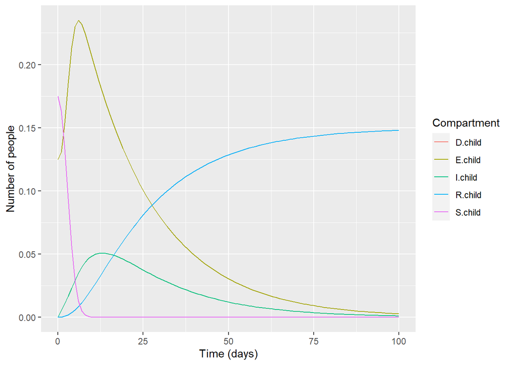

```r
create_child_plot(no_Hosp)
```

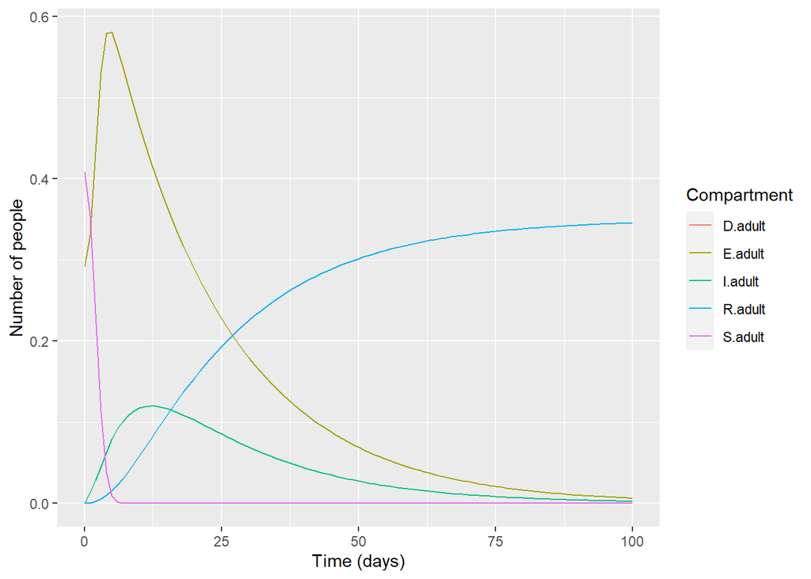

```r
create_adult_plot(no_Hosp)
```

### c.) Incorporate hospitalization. take into consideration two scenarios unlimited and limited bed capacity

### d.) For hospitalized individuals, specify a mortality rate due to critical illness.

### e.) Plot the trajectories of Susceptible, Exposed, Infected, Recovered, Hospitalized, and Dead sub-populations over time.

> **Hospitalization**
> 1. Unlimited hospital beds
> - $\mu_n$ hospitalized without being in critical condition `95%`
> - $\mu_h$ hospitalized and in critical condition `5%`
> - $i_h$ total number of hospital beds = N

> The whole population can be hospitalized at any given time
> 2. Limited hospital bed
> - $i_h$ can be reduced to bellow 100 % of the population
> - $\mu_h + \mu_n = i_h$

> For **limited hospitals** the program uses the standard world health organization (WHO) number of hospitals
> - **Low level economy** – `2.5` hospitals for every 1000 people
> - **Medium level economy** – `3.5` hospitals for every 1000 people
> - **High level economy** – `5` hospitals for every 1000 people

#### The differential equations

adding hospitalization means recovered individuals can be expressed as

$$\frac{dR}{dt} = \gamma *I_{child/adult} + \mu * I_{child/adult} *
hospitalized\ individuals\ NOT\ in\ critical\ condition$$

the dead people can be expressed as

$$\frac{dD}{dt} = \mu * I_{child/adult} * (1-hospitalized\ individuals\
NOT\ in\ critical\ condition)$$

**Hospitalization data**

```r
unlim_hosp = 1000/1000 * N
low_econ = 2.5/1000 * N
med_econ = 3.5/1000 * N
high_econ = 5/1000 * N
utopia_econ = 1/2 * N
ih = c(unlim_hosp, low_econ, med_econ, high_econ, utopia_econ)
muh = ih * 0.05
mun = ih * 0.95
```

```r
seird.with.hosp = function(time, state, parameters){
  S.c = state[1]
  S.a = state[2]
  E.c = state[3]
  E.a = state[4]
  I.c = state[5]
  I.a = state[6]
  R.c = state[7]
  R.a = state[8]
  D.c = state[9]
  D.a = state[10]
  with(as.list(parameters), {
    N.c = S.c + E.c + I.c + R.c + D.c
    N.a = S.a + E.a + I.a + R.a + D.a

    # weight of infection
    lambda = (beta * c2c * I.c/N.c) + (beta * c2a * I.a/N.a)

    # adults have a constant infection rate
    beta.a = (a2a * beta * I.a/N.c) +  (a2c * beta * I.a/N.a)

    # define the differential equations

    # child differential equations
    dSc = - lambda * S.c
    dEc = lambda * S.c - sigma * E.c
    dIc = sigma * E.c - (gamma + mu) *I.c
    dRc = gamma * I.c + (mu* I.c * mun)
    dDc = mu * I.c * (1-mun)

    # adult differential equations
    dSa = - beta.a * S.a
    dEa = beta.a * S.a - sigma * E.a
    dIa = sigma * E.a - (gamma + mu) * I.a
    dRa = gamma * I.a + (mu* I.a* mun)
    dDa = mu * I.a * (1-mun)

    # return the output of the differential equations
    return(list(c(dSc, dSa, dEc, dEa, dIc, dIa, dRc, dRa, dDc, dDa)))

  })
}
```

#### Fitting the model

```r
hosp_data = c() # stores the data on each number of hospitals
for(i in 1:length(muh)){
  parameters = c(b = beta, mu = mu, sigma = sigma, gamma = gamma, c2c = c2c.Contact, c2a = c2a.Contact, a2a = a2a.Contact, a2c = a2c.Contact, mun = mun[i])
  state = c(S.child = S.child, S.adult = S.adult,
          E.child = E.child, E.adult = E.adult,
          I.child = I.child, I.adult = I.adult,
          R.child = R.child, R.adult = R.adult,
          D.child = D.child, D.adult = D.adult)
  time = seq(0, 100, 1)
  hosp_data[[i]] = as.data.frame(ode(y = state, times = time, func = seird.with.hosp, parms = parameters))

}
length(hosp_data)
```

```
## [1] 5
```

#### Plotting the data

```r
unlimited_hospitals = data.frame(hosp_data[1])
low_economy = data.frame(hosp_data[2])
med_economy = data.frame(hosp_data[3])
high_economy = data.frame(hosp_data[4])
utopia = data.frame(hosp_data[5])
```

#### Unlimited hospitals

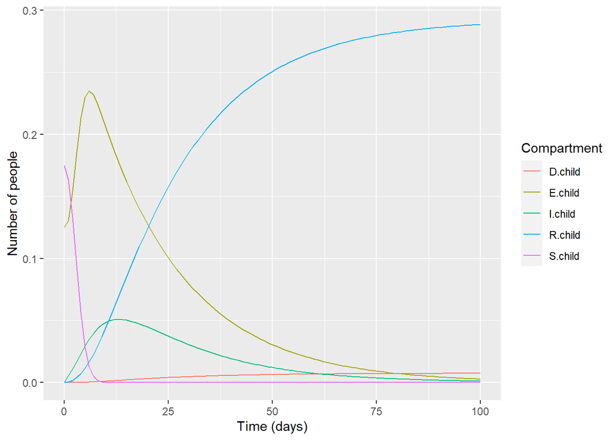

```r
create_child_plot(unlimited_hospitals)
```

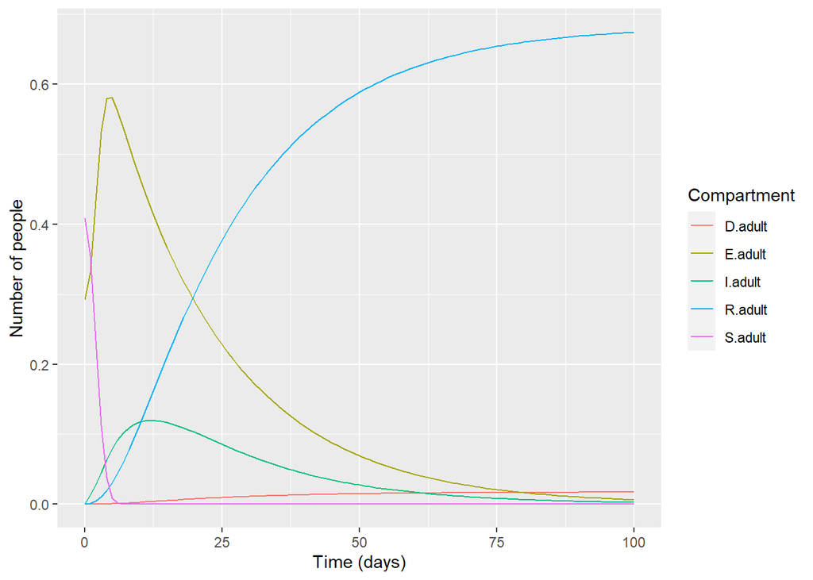

```r
create_adult_plot(unlimited_hospitals)
```

> because of unlimited hospitals death rate remains relatively low for both populations.

> The susceptible adults drop at a steeper rate as compared to the susceptible children. This is caused by the steeper rise in adult infected before the population of adults finally interacts with the children population.

> There is a significantly high recovery rate

> The population of adults seems to acquire hard immunity against the disease on day `10` while the child population acquires it two days later.

> from the graphs the population stabilizes on day `75` with individuals who die remaining constant rate after day 85 for adults

#### Low Economy Region

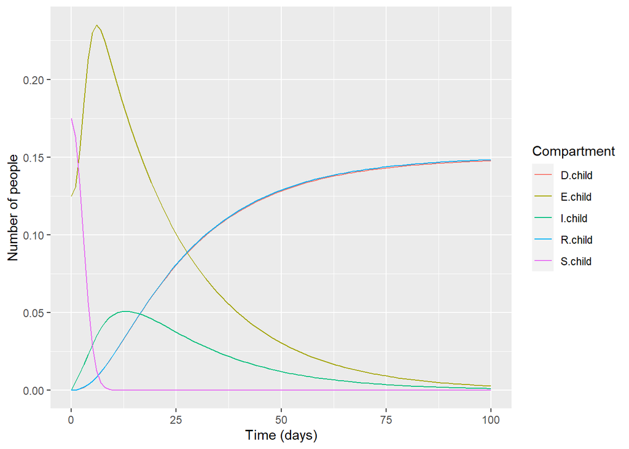

```r
create_child_plot(low_economy)
```

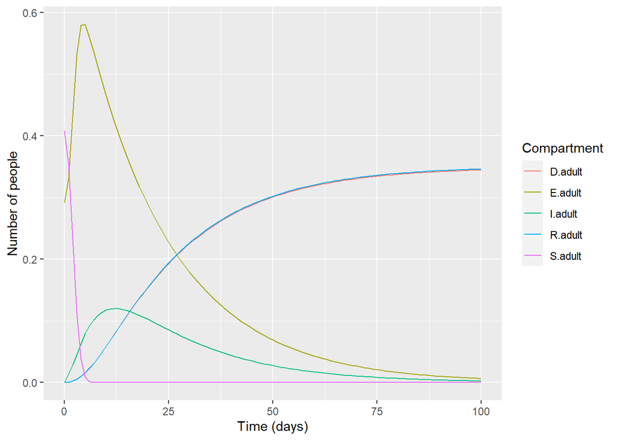

```r
create_adult_plot(low_economy)
```

#### Medium Economy Region

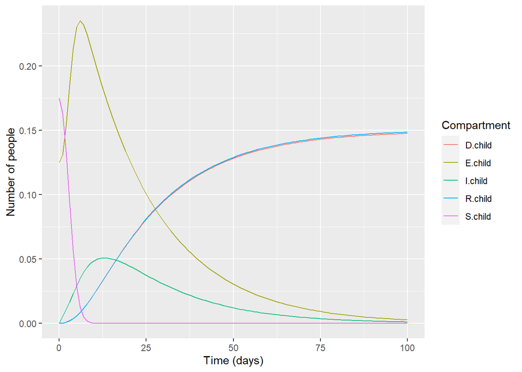

```r
create_child_plot(med_economy)
```

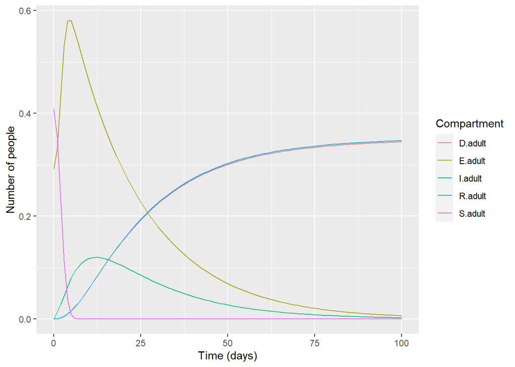

```r
create_adult_plot(med_economy)
```

#### High Ecomony

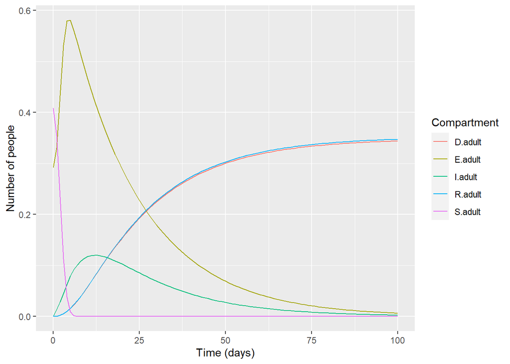

```r
create_adult_plot(high_economy)
```

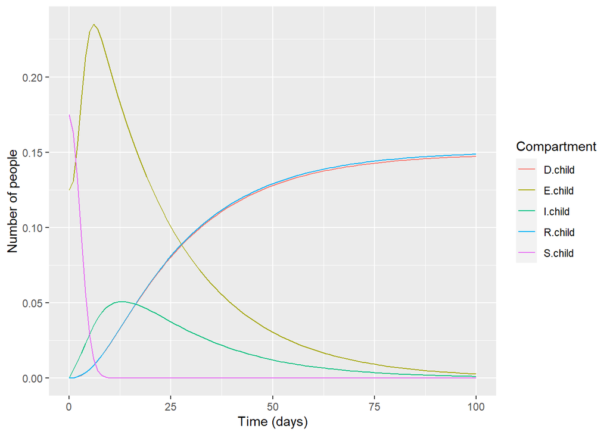

```r
create_child_plot(high_economy)
```

#### Utopia

an utopia was made with a 50% of all the individuals who are hospitalized being able to be hospitalized.

This was done to investigate the effect of increasing the number of hospitals

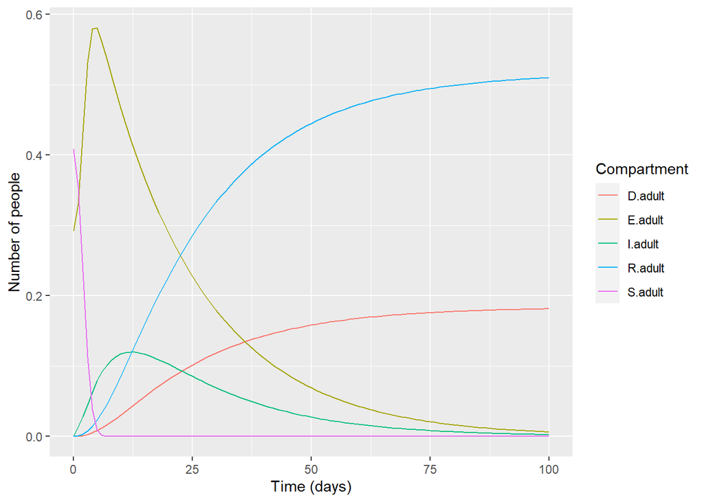

```r
create_adult_plot(utopia)
```

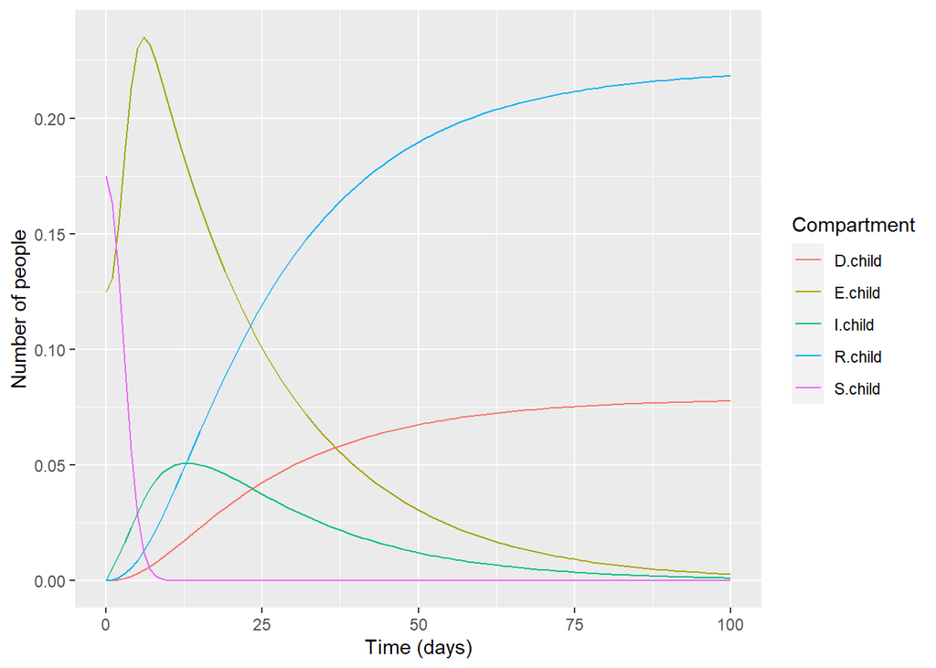

```r
create_child_plot(utopia)
```

The death rate is observed to be significantly lower backing up the hypothesized trend that more hospitals actually lower the death rate of individuals because of the disease

## 3.) Evaluate and Discuss Changes with Vaccination assuming a vaccine with 100% effectiveness against acquiring infections and analyze its impact on sub-populations.

#### a.) Introduce vaccination into the model, varying vaccination percentages (10%, 20%, 30%, 50%).

#### b.) Simulate and observe changes in the trajectories of Susceptible, Exposed, Infected, Recovered, Hospitalized, and Dead sub-populations.

#### c.) Discuss how different vaccination rates influence the epidemic dynamics, hospitalization rates, and mortality rates

> **If a vaccine is 100% effective**
> - The population or recovered individuals begins from a number larger than 0 because the vaccine ensure that individuals have been exposed to a denatured example of the disease and recovered never to be reinfected again at the start of the models
> - This also reduces the susceptible individuals in the population. This is because once a person has been vaccinated the disease no longer affects them

> **Parameters are Expressed as:**

> $$vaccinated = vaccinated\ percentage * population\\
> vaccinated\ children = child\ proportion * vaccinated\\
> susceptible\ child = sucscept\ child - vaccinated\ children\\
> recovered\ child = recover\ child + vaccinated\ children$$

> This is the same for the adults

```r
vaccination = c()
pop_vac = c(0.1, 0.2, 0.3, 0.5)
```

#### Model Parameters

The model assumes no hospitalization ratio between critical condition and just the regular outpatient care.

The model just takes that 5% of the infected individuals die.

```r
seir.vac = function(time, state, parameters){
  S.c = state[1]
  S.a = state[2]
  E.c = state[3]
  E.a = state[4]
  I.c = state[5]
  I.a = state[6]
  R.c = state[7]
  R.a = state[8]
  D.c = state[9]
  D.a = state[10]
  with(as.list(parameters), {
    N.c = S.c + E.c + I.c + R.c + D.c
    N.a = S.a + E.a + I.a + R.a + D.a

    # weight of infection
    lambda = (beta * c2c * I.c/N.c) + (beta * c2a * I.a/N.a)

    # adults have a constant infection rate
    beta.a = (a2a * beta * I.a/N.c) +  (a2c * beta * I.a/N.a)

    # define the differential equations

    # child differential equations
    dSc = - lambda * S.c
    dEc = lambda * S.c - sigma * E.c
    dIc = sigma * E.c - (gamma + mu) *I.c
    dRc = gamma * I.c
    dDc = mu * I.c * 0.05

    # adult differential equations
    dSa = - beta.a * S.a
    dEa = beta.a * S.a - sigma * E.a
    dIa = sigma * E.a - (gamma + mu) * I.a
    dRa = gamma * I.a
    dDa = mu * I.a * 0.05

    # return the output of the differential equations
    return(list(c(dSc, dSa, dEc, dEa, dIc, dIa, dRc, dRa, dDc, dDa)))
  })
}
```

#### Population Parameters

```r
for (i in 1:length(pop_vac)){
  vacnD = pop_vac[i] * N
  child.vacnD = 0.3 * vacnD
  vS.child = 0.3 * susc - child.vacnD
  vE.child = E.child
  vI.child = I.child
  vR.child = 0.3 * recvd + child.vacnD
  vD.child = D.child

  # the adult parameters
  adult.vacnD = 0.7 * vacnD
  vS.adult = 0.7 * susc - adult.vacnD
  vE.adult = E.adult
  vI.adult = I.adult
  vR.adult = 0.7 * recvd + adult.vacnD
  vD.adult = D.adult

  # models
  parameters = c(b = beta, mu = mu, sigma = sigma, gamma = gamma, c2c = c2c.Contact, c2a = c2a.Contact, a2a = a2a.Contact, a2c = a2c.Contact)
  state = c(S.child = vS.child, S.adult = vS.adult,
          E.child = vE.child, E.adult = vE.adult,
          I.child = vI.child, I.adult = vI.adult,
          R.child = vR.child, R.adult = vR.adult,
          D.child = vD.child, D.adult = vD.adult)
  time = seq(0, 100, 1)
  vaccination[[i]] = as.data.frame(ode(y = state, times = time, func = seir.vac, parms = parameters))

}
length(vaccination)
```

```
## [1] 4
```

#### Plot the data

```r
ten_perc = data.frame(vaccination[1])
twenty_perc = data.frame(vaccination[2])
thirty_perc = data.frame(vaccination[3])
fifty_perc = data.frame(vaccination[4])
```

#### a. 10% Vaccination

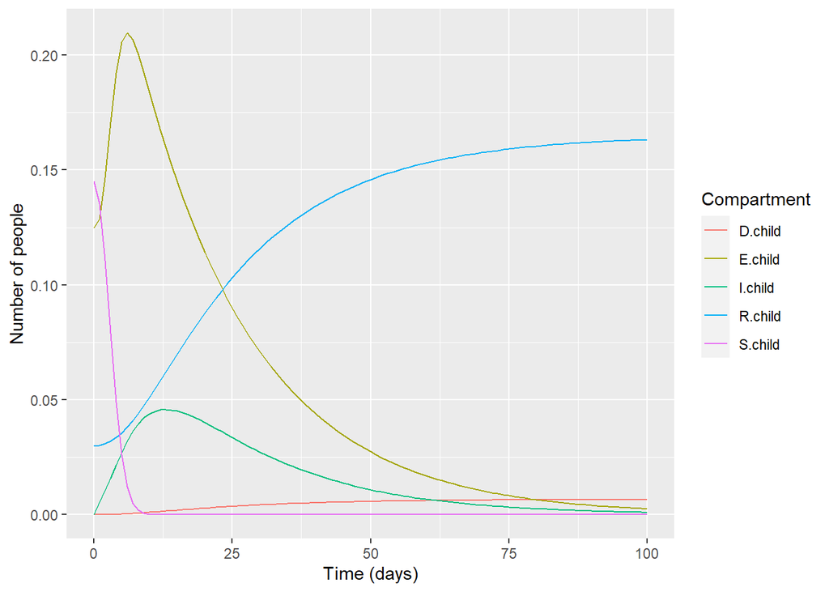

```r
create_child_plot(ten_perc)
```

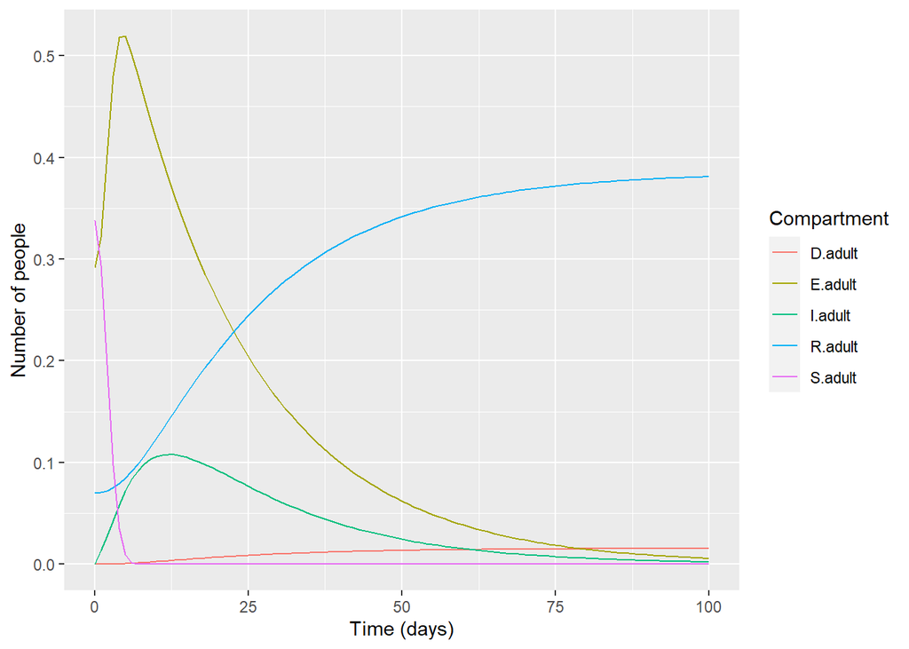

```r
create_adult_plot(ten_perc)
```

> **Interpretation**
> - because of vaccination the intersection between susceptible adults and children happens with a larger population number.
> - This means that the individual recovery is higher in each group because of the vaccination
> - The death rate is also significantly lower compared to the original no hospital data.
> - There is also a lower peak on the number of infected children and adults indicating the vaccine improves the surviveability from the disease.
> - Because of the steeper recovery graph as compared to the original no hospital data, the model illustrates that vaccination increases the opportunity to recover from the disease

#### b. 20% Vaccination

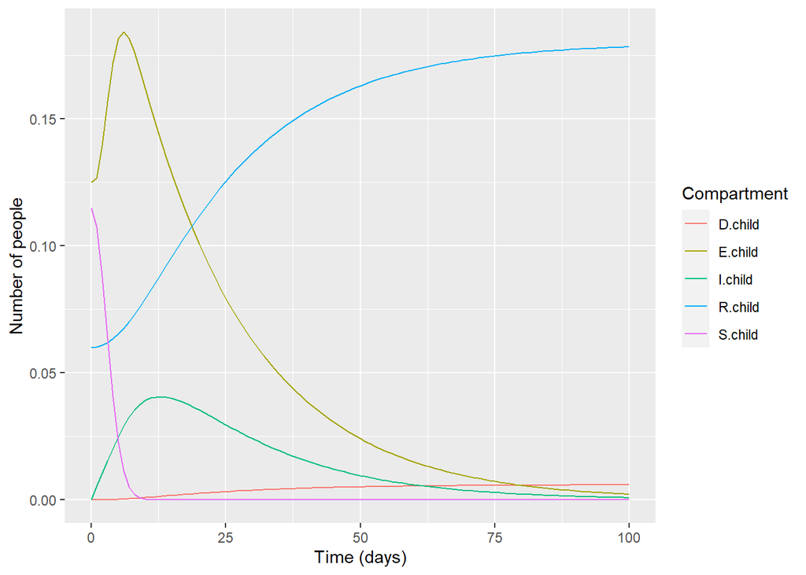

```r
create_child_plot(twenty_perc)
```

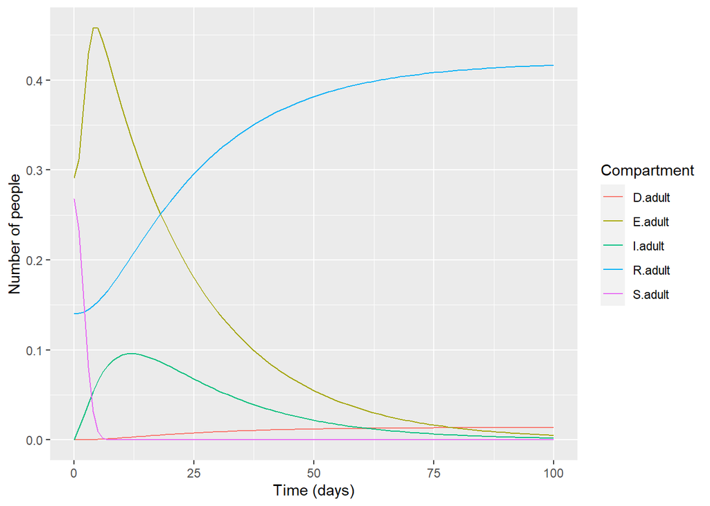

```r
create_adult_plot(twenty_perc)
```

> **Interpretation**

> excluding the shorter y-axis
> - The model indicates a lower death rate than the 10% vaccination.
> - There also seems to be no overlap of susceptible and exposed individuals after 20% vaccination.
> - This means once people are exposed they do not interact with the susceptible individuals. Because of this there is only a reduction in people ravaged by the disease
> - The lower peak of the infected graph also reflects this sentiment.
> - Increased number of vaccinated individuals in the population lowers the impact of the disease on the population

> hard immunity in this case is achieved on `day 25`

#### c. 30% Vaccination

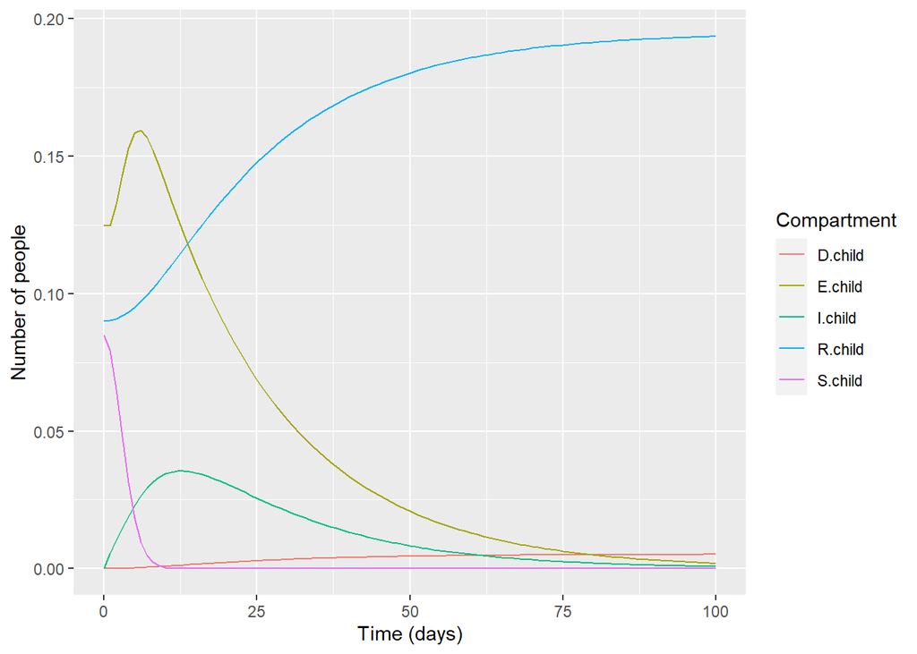

```r
create_child_plot(thirty_perc)
```

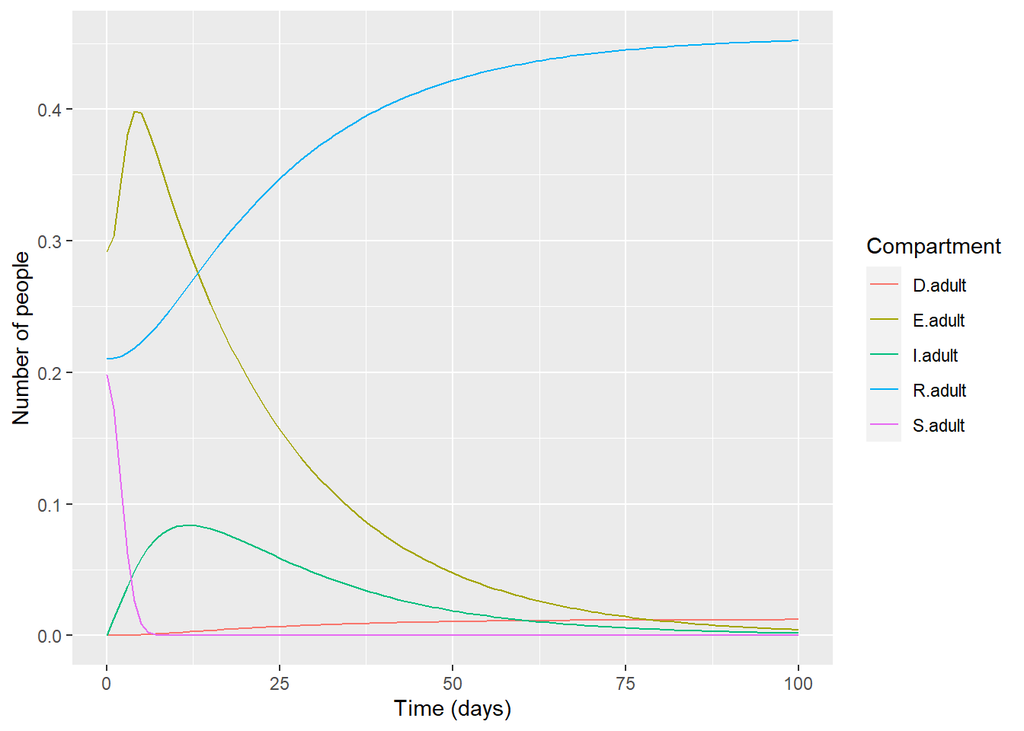

```r
create_adult_plot(thirty_perc)
```

> **Interpretation**

> The first notable improvement is that the hard immunity is achieved 12 days before the hard immunity for the `20%` vaccinated population.
> - The trend of no overlap between the susceptible and exposed individuals is also observed.
> - This means that the part of the population that is exposed can only recover and/or die. However, they can not infect any more of the population
> - There are continually lower peaks of the infected population indicating a reduce impact of the disease. The infection seems to only be isolated to the initial infected individuals and their immediate contacts

#### d. 50% Vaccination

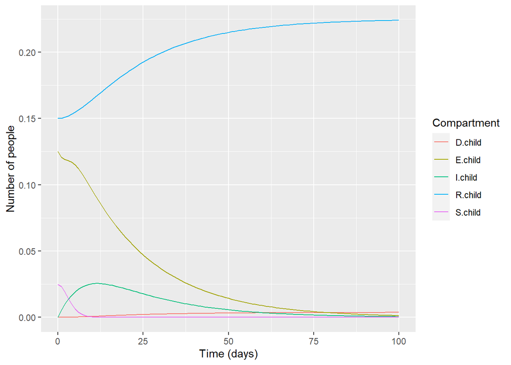

```r
create_child_plot(fifty_perc)
```

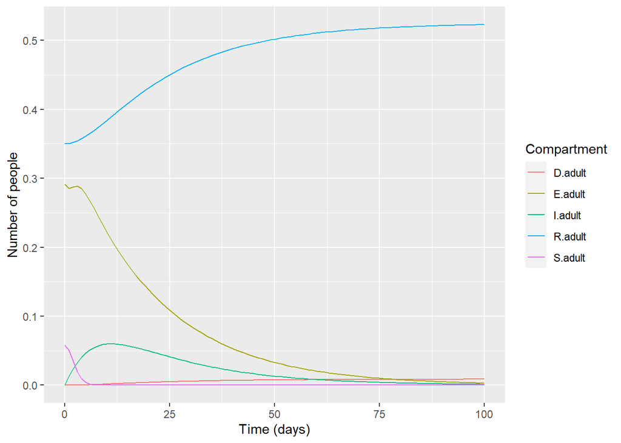

```r
create_adult_plot(fifty_perc)
```

> **Interpretation**

> There is also the most steep decline in exposed individuals because of this

> And, the death-rate becomes asymptotic to 0 but not rising away from 0
> - The exposed adult and child count matches the original population parameters before modeling the disease evolution
>   - 29.2 % of adults
>   - 12.5 % of children
> - this value reduces after it reaches this exact figures indicating no new exposure to the disease
> - the infected adult and child population rises slightly accommodating the initial exposed adults and children after which it drops immediately.
> - The population at 50% vaccination seems to only be able to recover and the unfortunate few die

> From the first day of simulation the population seems to have already acquired hard endemic immunity against the disease. Only the **initially** exposed and infected individuals seem to experience the effects of the disease.

## Conclusion

# References